# wk21_CBC

### Now let’s arrange the plots:

#### Figure 1

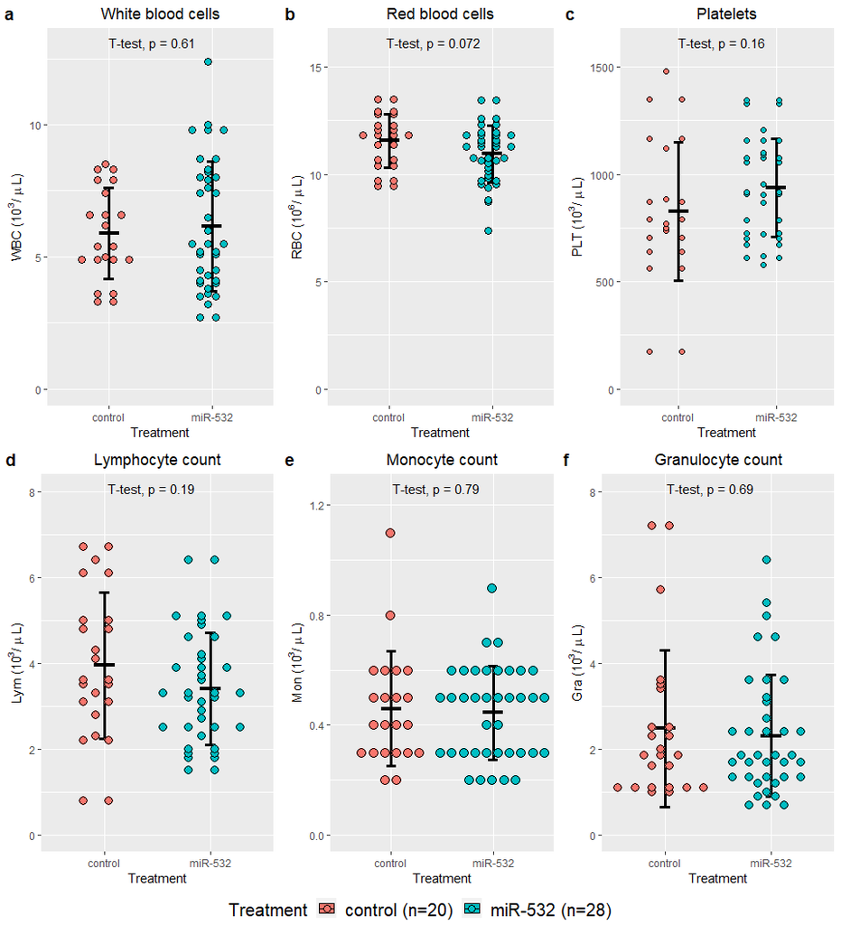

#### Figure 2

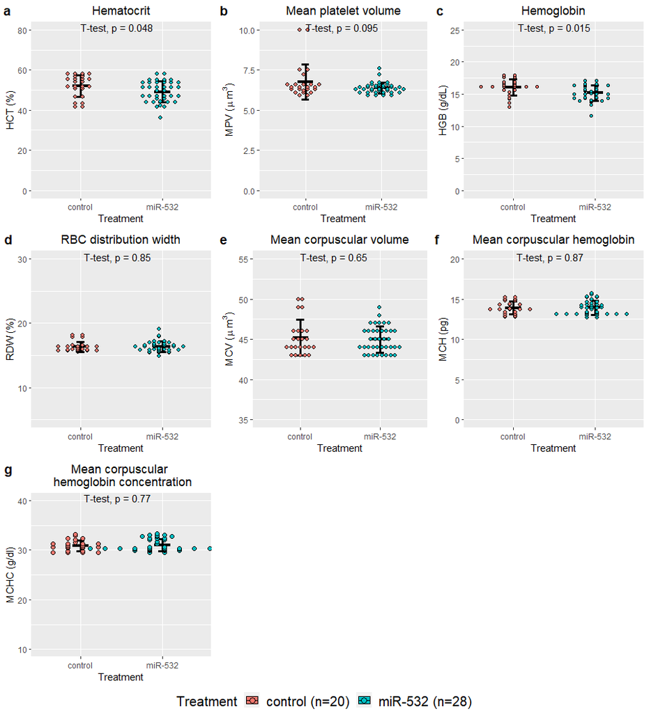

### Notes

The four miR-532 mice with high granulocytes and lower peripheral blood engraftment (37-45% GFP+) at week 5:

At week5  
ID, GFP+ %, Lym, Mon, Gra  
miR532-29, 43.2, 1.8, 0.9, 7.5  
miR532-14, 45.5, 1.1, 0.3, 5.6  
miR532-30, 37.4, 2.0, 0.8, 4.3  
miR532-8, 44.3, 0.9, 0.2, 4.0

At week11  
ID, GFP+ %, Lym, Mon, Gra  
miR532-29,  
miR532-14, 43.1, 3.0, 0.5, 5.8  
miR532-30,  
miR532-8, 55.0, 2.3, 0.4, 2.6

## Now lets separate the data based on the transplanter:

First, let’s take a look at our statistics

```
## # A tibble: 1 x 8
##   term        group1   group2     estimate conf.low conf.high p.adj p.adj.signif
## * <chr>       <chr>    <chr>         <dbl>    <dbl>     <dbl> <dbl> <chr>
## 1 Transplant~ Jeff.Lam Patrick.L~    -1.23    -2.87     0.412 0.138 ns
```

```
## # A tibble: 1 x 8
##   term      group1  group2   estimate conf.low conf.high      p.adj p.adj.signif
## * <chr>     <chr>   <chr>       <dbl>    <dbl>     <dbl>      <dbl> <chr>
## 1 Transpla~ Jeff.L~ Patrick~     2.16     1.61      2.70    1.71e-9 ****
```

```
## # A tibble: 1 x 8
##   term       group1  group2    estimate conf.low conf.high    p.adj p.adj.signif
## * <chr>      <chr>   <chr>        <dbl>    <dbl>     <dbl>    <dbl> <chr>
## 1 Transplan~ Jeff.L~ Patrick.~     1.58    0.940      2.22  1.53e-5 ****
```

```
## # A tibble: 1 x 8
##   term       group1  group2    estimate conf.low conf.high    p.adj p.adj.signif
## * <chr>      <chr>   <chr>        <dbl>    <dbl>     <dbl>    <dbl> <chr>
## 1 Transplan~ Jeff.L~ Patrick.~     8.65     6.53      10.8 7.27e-10 ****
```

```
## # A tibble: 1 x 8
##   term        group1   group2    estimate conf.low conf.high  p.adj p.adj.signif
## * <chr>       <chr>    <chr>        <dbl>    <dbl>     <dbl>  <dbl> <chr>
## 1 Transplant~ Jeff.Lam Patrick.~    -1.06    -2.11   -0.0112 0.0477 *
```

```
## # A tibble: 1 x 8
##   term      group1   group2   estimate conf.low conf.high     p.adj p.adj.signif
## * <chr>     <chr>    <chr>       <dbl>    <dbl>     <dbl>     <dbl> <chr>
## 1 Transpla~ Jeff.Lam Patrick~    -1.41    -1.78     -1.04   4.70e-9 ****
```

```
## # A tibble: 1 x 8
##   term        group1   group2     estimate conf.low conf.high p.adj p.adj.signif
## * <chr>       <chr>    <chr>         <dbl>    <dbl>     <dbl> <dbl> <chr>
## 1 Transplant~ Jeff.Lam Patrick.L~    -2.35    -2.63     -2.07     0 ****
```

```
## # A tibble: 1 x 8
##   term        group1   group2     estimate conf.low conf.high p.adj p.adj.signif
## * <chr>       <chr>    <chr>         <dbl>    <dbl>     <dbl> <dbl> <chr>
## 1 Transplant~ Jeff.Lam Patrick.L~    -102.    -333.      130.  0.38 ns
```

```
## # A tibble: 1 x 8
##   term        group1   group2     estimate conf.low conf.high p.adj p.adj.signif
## * <chr>       <chr>    <chr>         <dbl>    <dbl>     <dbl> <dbl> <chr>
## 1 Transplant~ Jeff.Lam Patrick.L~  -0.0500   -0.282     0.182 0.665 ns
```

```
## # A tibble: 1 x 8
##   term        group1   group2     estimate conf.low conf.high p.adj p.adj.signif
## * <chr>       <chr>    <chr>         <dbl>    <dbl>     <dbl> <dbl> <chr>
## 1 Transplant~ Jeff.Lam Patrick.L~    0.151   -0.423     0.725 0.596 ns
```

```
## # A tibble: 1 x 8
##   term        group1   group2     estimate conf.low conf.high p.adj p.adj.signif
## * <chr>       <chr>    <chr>         <dbl>    <dbl>     <dbl> <dbl> <chr>
## 1 Transplant~ Jeff.Lam Patrick.L~   -0.202    -1.10     0.694  0.65 ns
```

```
## # A tibble: 1 x 8
##   term        group1   group2    estimate conf.low conf.high  p.adj p.adj.signif
## * <chr>       <chr>    <chr>        <dbl>    <dbl>     <dbl>  <dbl> <chr>
## 1 Transplant~ Jeff.Lam Patrick.~   -0.121   -0.232   -0.0110 0.0321 *
```

```
## # A tibble: 1 x 8
##   term        group1   group2    estimate conf.low conf.high  p.adj p.adj.signif
## * <chr>       <chr>    <chr>        <dbl>    <dbl>     <dbl>  <dbl> <chr>
## 1 Transplant~ Jeff.Lam Patrick.~   -0.904    -1.84    0.0296 0.0573 ns
```

```
## # A tibble: 1 x 8
##   term        group1   group2     estimate conf.low conf.high p.adj p.adj.signif
## * <chr>       <chr>    <chr>         <dbl>    <dbl>     <dbl> <dbl> <chr>
## 1 Transplant~ Jeff.Lam Patrick.L~    -7.67    -21.9      6.57 0.282 ns
```

```
## # A tibble: 1 x 8
##   term        group1   group2     estimate conf.low conf.high p.adj p.adj.signif
## * <chr>       <chr>    <chr>         <dbl>    <dbl>     <dbl> <dbl> <chr>
## 1 Transplant~ Jeff.Lam Patrick.L~    -1.13    -4.46      2.21 0.491 ns
```

```
## # A tibble: 1 x 8
##   term       group1  group2    estimate conf.low conf.high    p.adj p.adj.signif
## * <chr>      <chr>   <chr>        <dbl>    <dbl>     <dbl>    <dbl> <chr>
## 1 Transplan~ Jeff.L~ Patrick.~     2.15     1.34      2.96  1.64e-5 ****
```

```
## # A tibble: 1 x 8
##   term      group1   group2   estimate conf.low conf.high     p.adj p.adj.signif
## * <chr>     <chr>    <chr>       <dbl>    <dbl>     <dbl>     <dbl> <chr>
## 1 Transpla~ Jeff.Lam Patrick~     2.38     1.64      3.11   9.36e-7 ****
```

```
## # A tibble: 1 x 8
##   term      group1   group2   estimate conf.low conf.high     p.adj p.adj.signif
## * <chr>     <chr>    <chr>       <dbl>    <dbl>     <dbl>     <dbl> <chr>
## 1 Transpla~ Jeff.Lam Patrick~     10.8     8.19      13.4   1.71e-8 ****
```

```
## # A tibble: 1 x 8
##   term        group1   group2     estimate conf.low conf.high p.adj p.adj.signif
## * <chr>       <chr>    <chr>         <dbl>    <dbl>     <dbl> <dbl> <chr>
## 1 Transplant~ Jeff.Lam Patrick.L~     1.39   -0.729      3.51 0.188 ns
```

```
## # A tibble: 1 x 8
##   term        group1   group2     estimate conf.low conf.high p.adj p.adj.signif
## * <chr>       <chr>    <chr>         <dbl>    <dbl>     <dbl> <dbl> <chr>
## 1 Transplant~ Jeff.Lam Patrick.L~   -0.511    -1.27     0.251 0.178 ns
```

```
## # A tibble: 1 x 8
##   term       group1   group2   estimate conf.low conf.high    p.adj p.adj.signif
## * <chr>      <chr>    <chr>       <dbl>    <dbl>     <dbl>    <dbl> <chr>
## 1 Transplan~ Jeff.Lam Patrick~    -1.98    -2.62     -1.34  1.88e-6 ****
```

```
## # A tibble: 1 x 8
##   term        group1   group2     estimate conf.low conf.high p.adj p.adj.signif
## * <chr>       <chr>    <chr>         <dbl>    <dbl>     <dbl> <dbl> <chr>
## 1 Transplant~ Jeff.Lam Patrick.L~    -174.    -489.      140. 0.263 ns
```

```
## # A tibble: 1 x 8
##   term        group1   group2     estimate conf.low conf.high p.adj p.adj.signif
## * <chr>       <chr>    <chr>         <dbl>    <dbl>     <dbl> <dbl> <chr>
## 1 Transplant~ Jeff.Lam Patrick.L~    0.417   -0.648      1.48 0.426 ns
```

```
## # A tibble: 1 x 8
##   term        group1   group2     estimate conf.low conf.high p.adj p.adj.signif
## * <chr>       <chr>    <chr>         <dbl>    <dbl>     <dbl> <dbl> <chr>
## 1 Transplant~ Jeff.Lam Patrick.L~    0.661  -0.0990      1.42 0.085 ns
```

```
## # A tibble: 1 x 8
##   term        group1   group2     estimate conf.low conf.high p.adj p.adj.signif
## * <chr>       <chr>    <chr>         <dbl>    <dbl>     <dbl> <dbl> <chr>
## 1 Transplant~ Jeff.Lam Patrick.L~    0.111    -1.59      1.81 0.894 ns
```

```
## # A tibble: 1 x 8
##   term        group1   group2     estimate conf.low conf.high p.adj p.adj.signif
## * <chr>       <chr>    <chr>         <dbl>    <dbl>     <dbl> <dbl> <chr>
## 1 Transplant~ Jeff.Lam Patrick.L~   -0.106   -0.434     0.223 0.512 ns
```

```
## # A tibble: 1 x 8
##   term        group1   group2     estimate conf.low conf.high p.adj p.adj.signif
## * <chr>       <chr>    <chr>         <dbl>    <dbl>     <dbl> <dbl> <chr>
## 1 Transplant~ Jeff.Lam Patrick.L~    -1.13    -2.89     0.624 0.195 ns
```

```
## # A tibble: 1 x 8
##   term       group1  group2    estimate conf.low conf.high    p.adj p.adj.signif
## * <chr>      <chr>   <chr>        <dbl>    <dbl>     <dbl>    <dbl> <chr>
## 1 Transplan~ Jeff.L~ Patrick.~    -37.4    -53.2     -21.6  6.62e-5 ****
```